# Simulation

Julian Frattini

2024-03-08

In this notebook, we perform a simulation of our assumptions to demonstrate the capability of a Bayesian model to recover the strength of effects causing the observed data.

## Data synthesis

Firstly, we synthesize a data set in which we know the effect of certain variables on our response variable. We determine `n.participants` participants and assume a $2\times2$ factorial crossover design. This means, the synthesized data set simulates an experiment with 2 levels of the main factor (i.e., baseline and treatment) administered to every participant in 2 periods. Per period, we assume taking `n.measures` number of measures.

```r
# number of hypothesized participants in the experiment
n.participants <- 50

# number of periods
n.periods <- 2
periods <- data.frame(
  period = seq(1, n.periods)
)

# number of measures
n.measures <- 1
measures <- data.frame(
  measure = seq(1, n.measures)
)
```

Next, we determine the strength of the effect that each variable has on the response variable. To avoid researcher bias, we randomly sample these effect strength values from a random distribution $\mathcal{N}(0, 1)$.

```r
effects <- rnorm(6, 0, 1)

e.baseline <- effects[1]
e.treatment <- effects[2]
e.skill <- effects[3]
e.crossover.AB <- effects[4] # baseline -> treatment
e.crossover.BA <- effects[5] # treatment -> baseline
e.learning <- effects[6]
```

```r
d.effects <- data.frame(
  Effect = c("Baseline (Intercept)", "Treatment", "Individual skill", "Carryover Effect (AB)", "Carryover Effect (BA)", "Learning Effect"),
  Strength = c(e.baseline, e.treatment, e.skill, e.crossover.AB, e.crossover.BA, e.learning)
)

d.effects %>% knitr::kable("simple")
```

| Effect | Strength |
| --- | --- |
| Baseline (Intercept) | 1.3709584 |
| Treatment | -0.5646982 |
| Individual skill | 0.3631284 |
| Carryover Effect (AB) | 0.6328626 |
| Carryover Effect (BA) | 0.4042683 |
| Learning Effect | -0.1061245 |

We construct a data frame of participants, consisting of their ID, a randomly assigned skill value (also $\mathcal{N}(0, 1)$) representing their inherent capability, and an assignment to a experimental group (either AB (`group=1`), which receives the treatment in period 2, or group BA (`group=2`), which receives the treatment in period 1). The two variables of participants that influence the response variable (group and skill) are not correlated.

```r
# generate IDs for each participant
participants.id <- seq(1, n.participants)

# randomly assign a "skill" value to each participant
participants.skill <- rnorm(n.participants, 0, 1)

# assemble a data frame of participants
participants <- data.frame(
  PID = participants.id,
  skill = participants.skill,
  group = rep(c(1, 2), n.participants/2) # assignment of participants to groups
)
```

Finally, we generate synthetic values of the `response` variable according to our causal model. This means, the response variable is calculated via random draws from a normal distribution where the mean $\mu$ is calculated via all causal variables according to their respective effect strength. We set the standard deviation $\sigma$ to 0.3, which introduces slight variation around the calculated values.

```r
observations <- participants %>%
  cross_join(measures) %>%
  cross_join(periods) %>%
  mutate(treatment = (group!=period)) %>%
  rowwise() %>%
  mutate(
    response = rnorm(1, e.baseline + e.treatment*treatment + e.learning*(period-1) + e.skill*skill + e.crossover.AB*(period-1)*(abs(group-2)), 0.3)
    #response = rnorm(1, e.baseline + e.treatment*treatment + e.learning*(period-1) + e.skill*skill + e.crossover.AB*(period-1)*(abs(group-2)) + e.crossover.BA*(period-1)*(group-1), 0.3)
  )
```

We define the carryover effect to be the difference in the response variable in period 2 in the two different groups. It does not matter whether we add this difference to the response variable values of group 1 or group 2, as long as we do not add a value to both. If we added a value each to both and they both had the same sign, the carryover effect becomes indistinguishable from the learning effect.

## Data Visualization

We visualize the distribution of the response variable stratified by different factors.

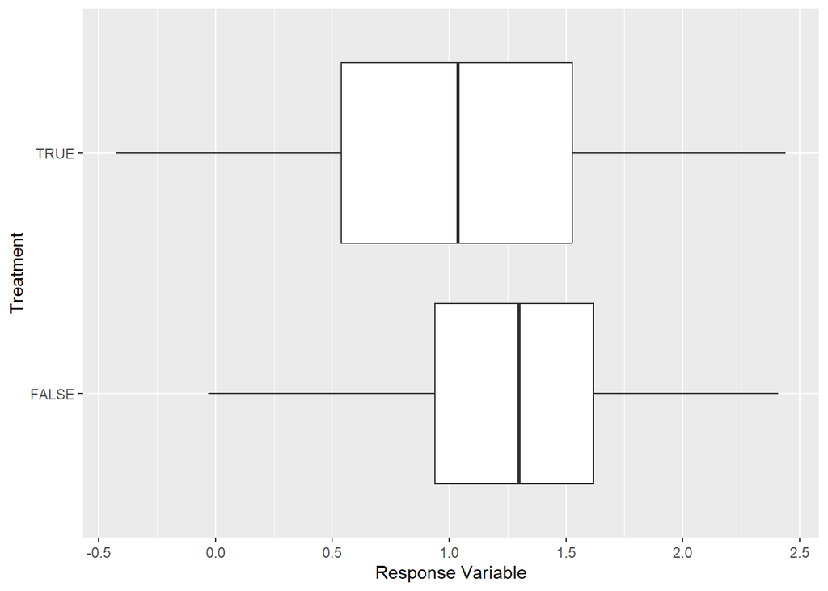

```r
observations %>% ggplot(aes(y=as.factor(treatment), x=response)) +
  geom_boxplot() +
  labs(x = "Response Variable", y = "Treatment")
```

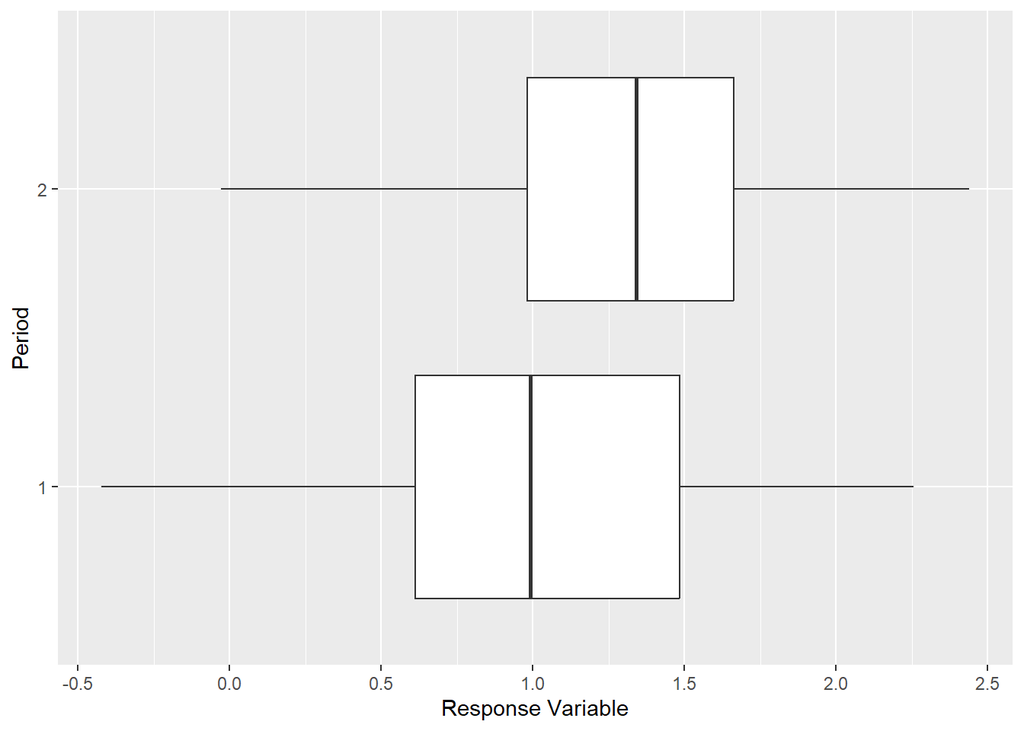

```r
observations %>% ggplot(aes(y=as.factor(period), x=response)) +
  geom_boxplot() +
  labs(x = "Response Variable", y = "Period")
```

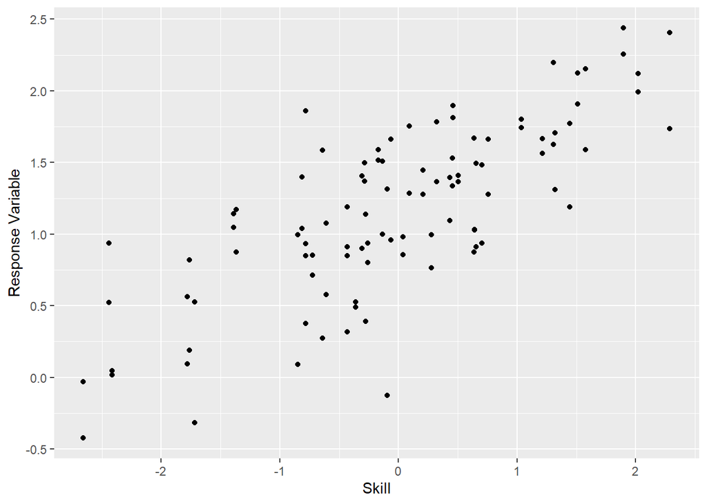

```r
observations %>% ggplot(aes(x=skill, y=response)) +
  geom_point() +
  labs(x = "Skill", y = "Response Variable")
```

The visualization of the carryover effect shows how the two sequences differ. In group AB, the distribution of the response variable for period 2 is influenced by the inercept, the learning effect, the treatment, and the carryover effect. In group BA, the distribution of the response variable for period 2 is only influenced by the intercept and the learning effect.

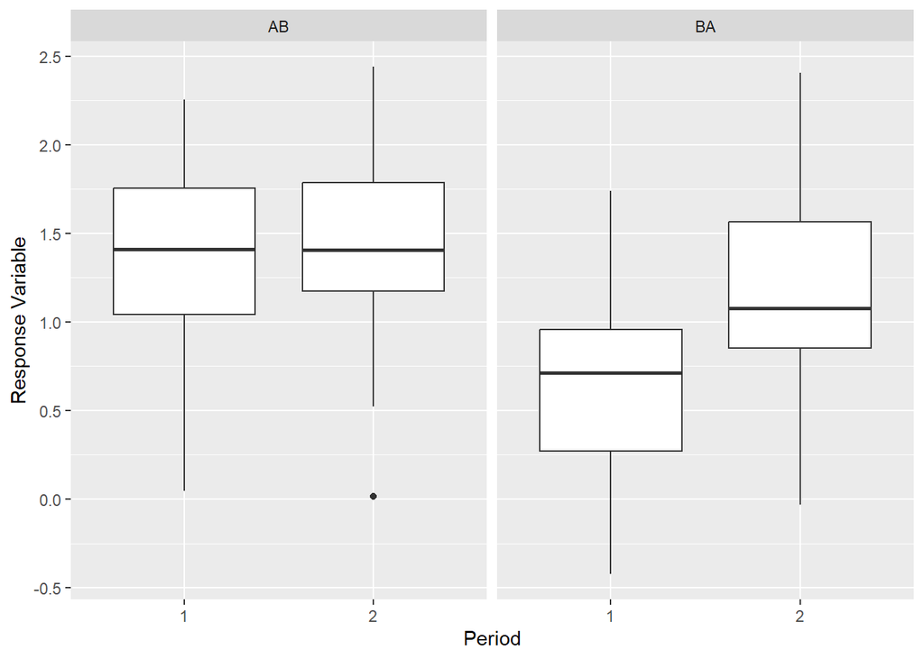

```r
observations %>%
  ggplot(aes(x=as.factor(period), y=response)) +
  geom_boxplot() +
  facet_grid(. ~ group, labeller = as_labeller(c("1" = "AB", "2"="BA"))) +
  labs(x = "Period", y = "Response Variable")
```

## Data Analysis

Now, we analyze the data with our proposed approach.

### Formula and Priors

We define a linear model that determines the `response` variable in relation to the causally related variables. The formula consists of the following terms:

| Term | Variable | Meaning |
| --- | --- | --- |
| `1` | Intercept | Fixed effect (population-wise) on the response variable |
| `treatment` | Treatment | Effect of the treatment |
| `period` | Learning | Effect of repeating the experimental task |
| `treatment*period` | Carryover | Effect of administering the treatment in period 1 on period 2 |
| `(1\|PID)` | Skill | Random effect (group-wise) of the capability of each participant |

The `treatment` and `period` term are added automatically via the `treatment*period` interaction.

```r
f1 <- response ~ 1 + treatment*period + (1|PID)

get_prior(f1, data=observations, family=gaussian)
```

```
##                   prior     class                 coef group resp dpar nlpar lb
##                  (flat)         b
##                  (flat)         b               period
##                  (flat)         b        treatmentTRUE
##                  (flat)         b treatmentTRUE:period
##  student_t(3, 1.2, 2.5) Intercept
##    student_t(3, 0, 2.5)        sd                                             0
##    student_t(3, 0, 2.5)        sd                        PID                  0
##    student_t(3, 0, 2.5)        sd            Intercept   PID                  0
##    student_t(3, 0, 2.5)     sigma                                             0
##  ub       source
##          default
##     (vectorized)
##     (vectorized)
##     (vectorized)
##          default
##          default
##     (vectorized)
##     (vectorized)
##          default
```

We select uninformative priors, which are mainly normal distributions centered around the mean 0 ($\mathcal{N}(0, 1)$). This ensures that we introduce no bias to the resulting posterior predictions.

```r
priors1 <- c(
  prior(normal(0, 1), class=Intercept),
  prior(normal(0, 1), class=b)
)

ndraws <- 100
```

We sample draws directly from the priors (i.e., sample without the model updating its parameter distributions based on the observed data) to evaluate the feasibility of the priors.

```r
m1.prior <-
  brm(data = observations, family = gaussian, f1, prior = priors1,
    iter = 4000, warmup = 1000, chains = 4, cores = 4,
    seed = 4, sample_prior="only"
  )
```

With the samples from the prior distributions, we conduct a prior predictive check to ensure that the priors are appropriate, i.e., the actual observations are realistic given the prior knowledge of the model.

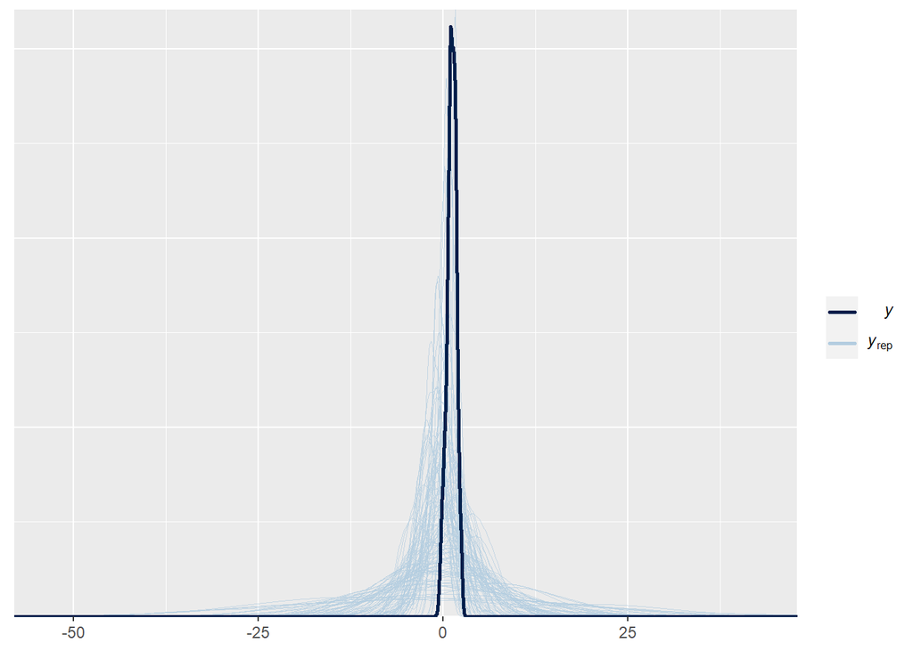

```r
brms::pp_check(m1.prior, ndraws=ndraws)
```

The distribution of draws encompasses the actually observed data, meaning that the actual observations lie within the realm of belief defined by the priors. We accept our priors as feasible.

### Model Training

With the appropriateness of priors confirmed, we train the model on the actual data.

```r
m1 <-
  brm(data = observations, family = gaussian, f1, prior = priors1,
    iter = 4000, warmup = 1000, chains = 4, cores = 4,
    seed = 4
  )
```

Again, we perform a posterior predictive check to ensure that the predictions of the model are feasible.

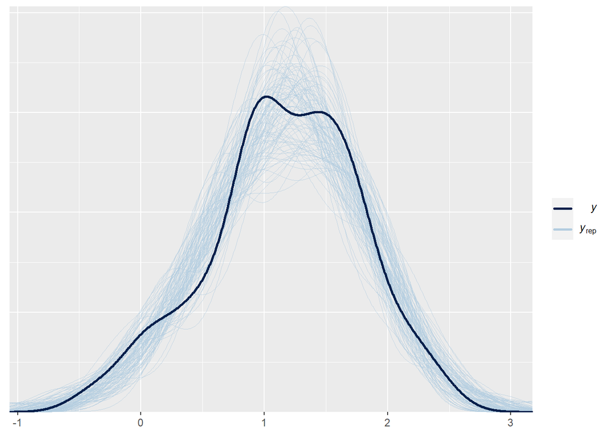

```r
brms::pp_check(m1, ndraws=ndraws)
```

The distribution of draws still encompasses the actually observed data and additionally grew closer to it (compared to the prior predictive check). This means that the coefficient distributions have improved and the model has learned.

### Model Evaluation

Finally, we evaluate the resulting model.

```r
summary(m1)
```

```
##  Family: gaussian
##   Links: mu = identity; sigma = identity
## Formula: response ~ 1 + treatment * period + (1 | PID)
##    Data: observations (Number of observations: 100)
##   Draws: 4 chains, each with iter = 4000; warmup = 1000; thin = 1;
##          total post-warmup draws = 12000
##
## Group-Level Effects:
## ~PID (Number of levels: 50)
##               Estimate Est.Error l-95% CI u-95% CI Rhat Bulk_ESS Tail_ESS
## sd(Intercept)     0.47      0.06     0.37     0.60 1.00     2420     4932
##
## Population-Level Effects:
##                      Estimate Est.Error l-95% CI u-95% CI Rhat Bulk_ESS
## Intercept                1.45      0.23     1.00     1.89 1.00     2146
## treatmentTRUE           -1.39      0.39    -2.15    -0.61 1.00     1968
## period                  -0.12      0.14    -0.39     0.16 1.00     2199
## treatmentTRUE:period     0.77      0.26     0.25     1.27 1.00     1952
##                      Tail_ESS
## Intercept                3639
## treatmentTRUE            3561
## period                   4231
## treatmentTRUE:period     3449
##
## Family Specific Parameters:
##       Estimate Est.Error l-95% CI u-95% CI Rhat Bulk_ESS Tail_ESS
## sigma     0.28      0.03     0.23     0.35 1.00     4195     6801
##
## Draws were sampled using sampling(NUTS). For each parameter, Bulk_ESS
## and Tail_ESS are effective sample size measures, and Rhat is the potential
## scale reduction factor on split chains (at convergence, Rhat = 1).
```

#### Fixed Effects

First, we investigate the coefficients of fixed effects to see how well they align with the effect strength that we determined before.

```r
# obtain the fixed effects in the model
coefs.fixed <- data.frame(fixef(m1, summary = TRUE))

# make the name of the factor (which was previously the index of the data frame) an explicit column
coefs.fixed <- cbind(factor = rownames(coefs.fixed), coefs.fixed)

# add a numeric column to the updated data frame
rownames(coefs.fixed) <- 1:nrow(coefs.fixed)
```

Then we add a column to our data frame containing the actual effects defined by us where the names of the factors align with the output from the model.

```r
d.effects.coefs <- cbind(factor = c(
  'Intercept', 'treatmentTRUE', 'PID', 'treatmentTRUE:period', 'treatmentFALSE:period', 'period'
  ), d.effects) %>%
  filter(factor %in% coefs.fixed$factor)
```

Now, we can visualize the mean and confidence interval of the calculated coefficient distributions (black errorbars) and compare them to the actual effect defined by us (red dot).

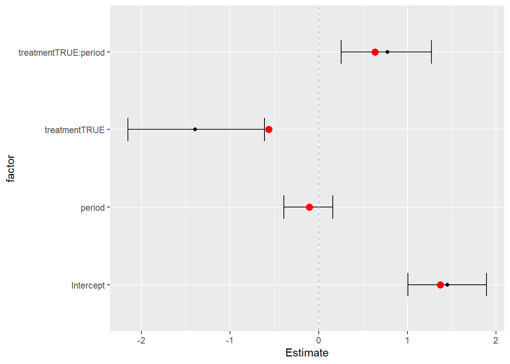

```r
coefs.fixed %>% ggplot(aes(y=factor)) +
  geom_point(aes(x=Estimate)) +
  geom_errorbar(aes(xmin=Q2.5, xmax=Q97.5), width=0.3) +
  geom_point(aes(x=Strength), data=d.effects.coefs, size=3, color="red") +
  geom_vline(xintercept = 0, linetype="dashed", color="grey")
```

#### Random Effects

The random effect of the participant ID `(1|PID)` should model the `skill` value of each participant. We would expect that the intercept of the random effect equals the skill value times the skill effect.

```r
PID.impact <- data.frame(ranef(m1)[1]$PID)
```

A scatter plot visualizes the distribution of $participants.skill \times e.skill$ against the mean intercept of each participant.

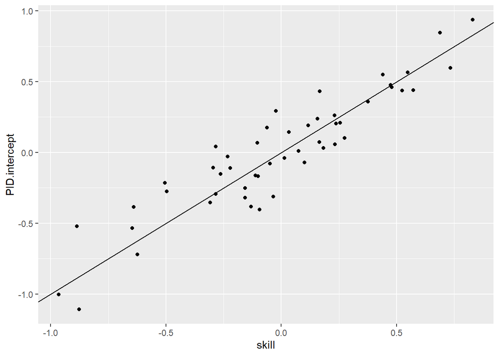

```r
data.frame(
  skill = participants.skill * e.skill,
  PID.intercept = PID.impact$Estimate.Intercept
) %>%
  ggplot(aes(x=skill, y=PID.intercept)) +
  geom_point() +
  geom_abline(intercept = 0, slope=1)
```

We can quantify this correlation by calculating a correlation coefficient. Firstly, we determine whether the two distributions are normally distributed.

```r
shapiro.test(participants.skill)
```

```
##
##  Shapiro-Wilk normality test
##
## data:  participants.skill
## W = 0.982, p-value = 0.6386
```

```r
shapiro.test(PID.impact$Estimate.Intercept)
```

```
##
##  Shapiro-Wilk normality test
##
## data:  PID.impact$Estimate.Intercept
## W = 0.98578, p-value = 0.8044
```

The Shapiro-Wilk tests suggests that both distributions are normal. This is as expected, since $participants.skill \sim \mathcal{N}(0, 1)$ and the intercepts per PID should resemble it. Consequently, we can calculate the Pearson correlation coefficient.

```r
cor.test(x=participants$skill, y=PID.impact$Estimate.Intercept, method="pearson")
```

```
##
##  Pearson's product-moment correlation
##
## data:  participants$skill and PID.impact$Estimate.Intercept
## t = 16.201, df = 48, p-value < 2.2e-16
## alternative hypothesis: true correlation is not equal to 0
## 95 percent confidence interval:
##  0.8616172 0.9537181
## sample estimates:
##       cor
## 0.9194532
```

This confirms that the inclusion of a participant-level random effect `(1|PID)` adequately models the individual skill of a participant and factors it out from the relationship of interest.